# Introduction to RStudio

Day 1 - Introduction to Data Analysis with R

Selina Baldauf

Freie Universität Berlin - Theoretical Ecology

October 17, 2026

## Difference between R and RStudio

[figure not shown]

Analogy and image from [ModernDive Book](https://moderndive.com/1-getting-started.html#r-rstudio)

R is the **programming language** and the **program** that does the actual work

RStudio is the **integrated development environment** (IDE).

Interface to R, syntax highlighting, file management, …

## A quick tour around RStudio

[figure not shown]

## A quick tour around RStudio

[figure not shown]

## Console pane

- Execute R code
- Output from R code in scripts is printed there
- Type a command into the console and execute with `Enter/Return`

**Tip**

Use arrow keys to bring back last commands

[figure not shown]

## Script pane

- Write scripts with R code
  - Scripts are text files with R commands (file ending `.R`)
  - Use scripts to save commands for reuse

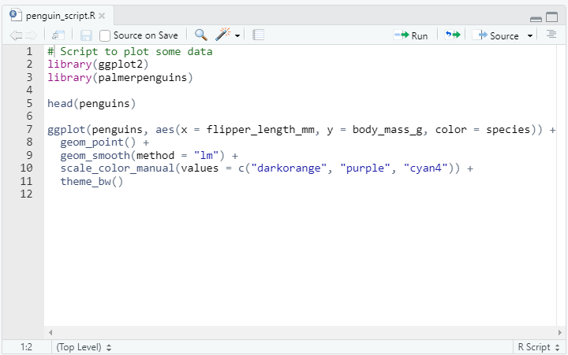

## Script pane

- Create a new R script:  
  **File -> New File -> R Script**
- Save an R script:  
  **File->Save (Ctrl/Cmd + S)**
- Run code line by line with **Run button (Ctrl+Enter/Cmd+Return)**
- You can open multiple scripts

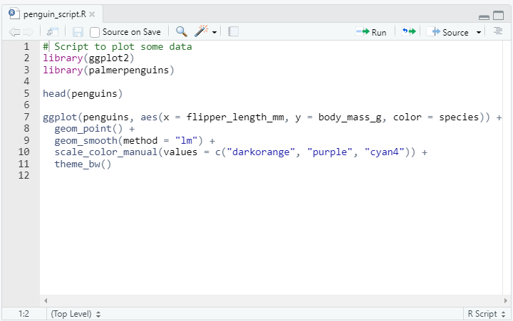

**Script vs Console**

Use **scripts** for all your analysis and for commands that you want to save.  
Use **console** for temporary commands, e.g. to test something.

## Environment pane

- Shows objects currently present in the R session
- Is empty if you start R

[figure not shown]

## Files pane

- Similar to Explorer/Finder
- Browse project structure and files
  - Find and open files
  - Create new folders
  - Delete and rename files
  - …

[figure not shown]

## Plot pane

- Plots that are created with R will be shown here

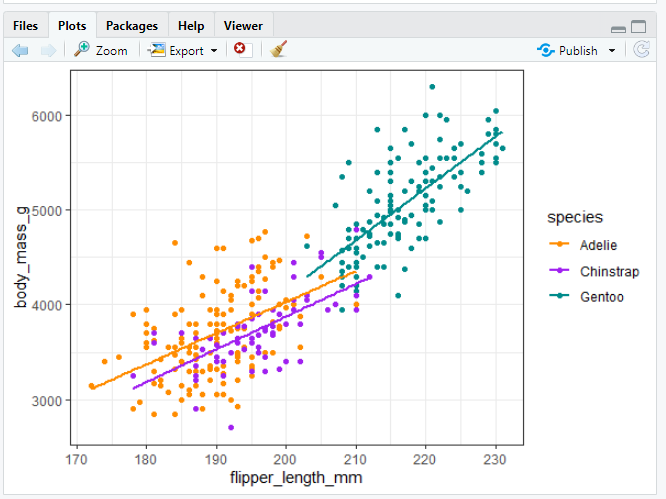

## Project-oriented workflow

**One project = one folder**

- Contains everything: data, scripts, figures, …
- Nothing important is somewhere else (Desktop, Downloads, …)
- The folder is **self-contained**: move it, share it, open on another computer, …

```
MyProject/
├── data/
│   └── tree_data.csv
├── R/
│   ├── clean_data.R
│   └── statistics.R
└── figures/
```

## RStudio projects

An **RStudio project** turns this folder into a workspace for R:

- It’s just a normal folder with an **.Rproj** file in it
- Opening the .Rproj file opens the entire project in RStudio
- Helps R to find your project files

```
MyProject/
├── data/
│   └── tree_data.csv
├── R/
│   ├── clean_data.R
│   └── statistics.R
├── figures/
└── MyProject.Rproj
```

Same folder, plus an .Rproj file

## Create an RStudio project

Create a project from scratch:

1. **File -> New Project -> New Directory -> New Project**
2. Enter a directory name (this will be the name of your project)
3. Choose the Directory where the project should be initiated
4. **Create Project**

[figure not shown]

Example RStudio project structure in the Files pane

RStudio will now create and open the project for you.

## Navigate an RStudio project

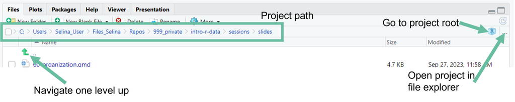

## Open an RStudio project

**From file explorer/finder:**  
Double click on the **.Rproj** file

[figure not shown]

**From inside RStudio:**  
Click the project symbol on the top right

[figure not shown]

# Now you

Task (15 min)

Set up your own RStudio project for this workshop

**Find the task description [here](https://selinazitrone.github.io/intro-r-data-analysis/sessions/01_intro-rstudio.html)**